# Extracting Information from Blood Cells

## Goal

#### Why it matters

- These models can help aid humans in blood differential tests
- A [blood differential test](https://www.ucsfhealth.org/medical-tests/blood-differential-test#:~:text=Neutrophils%3A%2040%25%20to%2060%25,Eosinophils%3A%201%25%20to%204%25) involves counting the number of various types of white blood cells and comparing them to other types, which ensure various treatments are having desired effects.
- It is also a step in diagnosing 'an infection, anemia, or leukemia'.
- Neutrophils, for example, are the most common composing 40-60% of all white blood cells .
- In order to perform this test a blood sample is taken, stained, and cells are then counted, typically by a person, This process could be greatly expedited by removing the need for a human to count the cells.

## The Data

The dataset consists of roughly 17000 .jpgs of size 360 $\times$ 363. Each image is of a healthy cell not undergoing any sort of treatment. There are 8 types: neutrophils, eosinophils, basophils, lymphocytes, monocytes, immature granulocytes, erythroblasts, and platelets (which are not included in our analysis as opening the file results in a crash).

Erythroblast

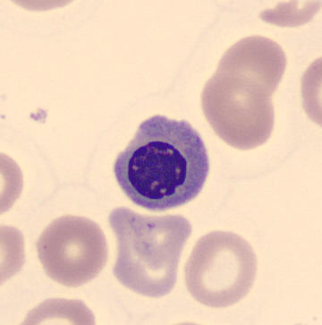

Neutrophil

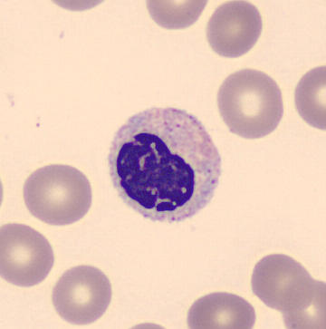

Monocyte

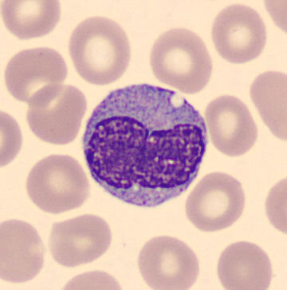

**As our dataset is number of images we had to find a way to represent the shape of interest within the image. In order to do this we use scikit image to find contours along the edges of each cell. This output an array of booleans at each pixel, to this we applied a search algorithm which output the path coordinates of the curve contained in this array.**

## Demonstration of how extracting cell nucleus shape works. This work was done using python.

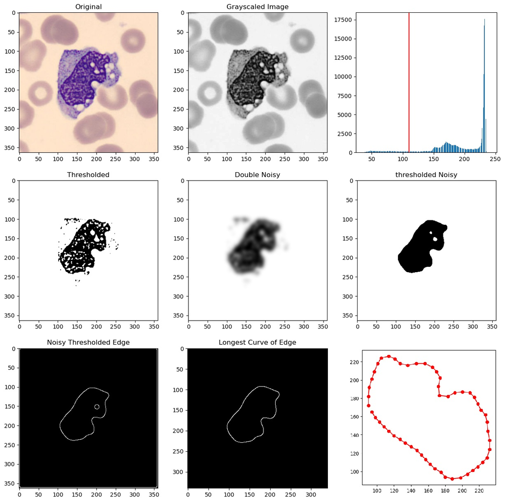

## Demonstration of how extracting cell membrane shape works

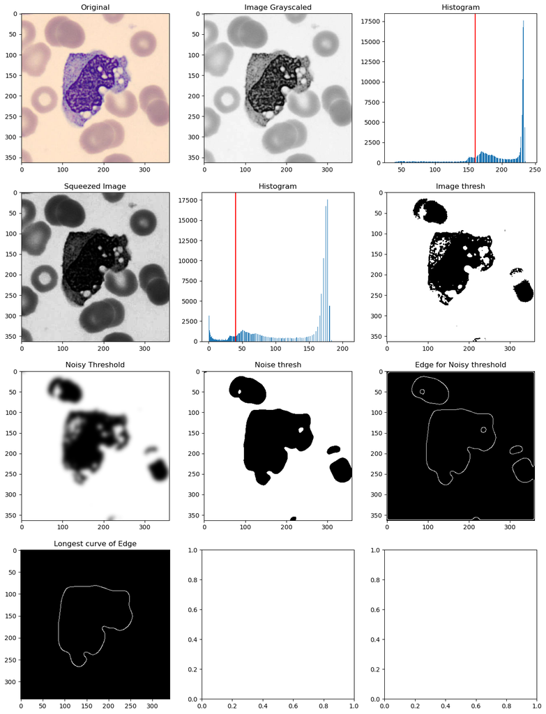

## Demonstration of how extracting cell membrane color works.

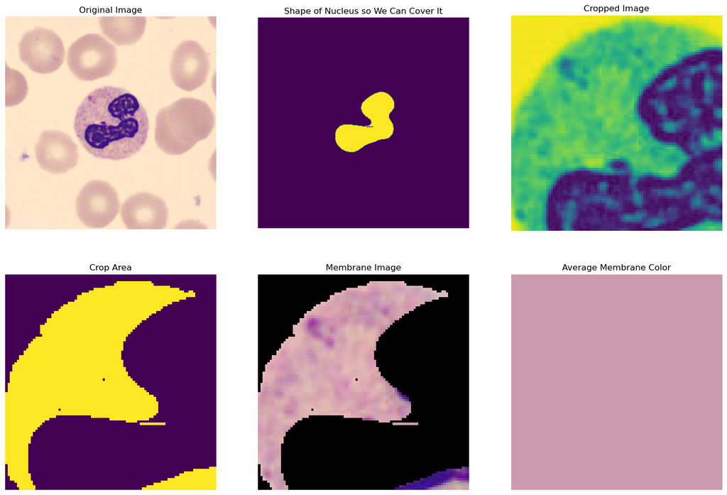

Some of the disadvantages of CNNs and why we should use Geometric Machine Learning Models:

- They don't encode position and orientation well
- Needs a lot of data for training
- Recognize the image as clusters of pixels which are arranged in distinct patterns. They don’t understand them as components of the image.

Issues with most medical cell data:

- The cells caputered in the images can be in different parts of the image
- It is hard to get a lot of cell data (our dataset is one of the exceptions)
- Classification of cells was done based off of sight. Humans are good at reconizing shapes and relationships between shapes. Not relationships between pixels

How Geometric Machine Learning resolves some of these issues: